# Manejando series de tiempo de financieras con R

# Pruebas de Autocorrelación

```r
Box.test(apple_retl_num, lag=15, type="Ljung")
Box.test(apple_retl_num, lag=30, type="Ljung")
```

```
	Box-Ljung test

data:  apple_retl_num
X-squared = 28.546, df = 15, p-value = 0.01839
```

```
	Box-Ljung test

data:  apple_retl_num
X-squared = 51.193, df = 30, p-value = 0.009293
```

```r
Box.test(apple_retl_num^2, lag=15, type="Ljung")
Box.test(apple_retl_num^2, lag=30, type="Ljung")
```

```
	Box-Ljung test

data:  apple_retl_num^2
X-squared = 85.922, df = 15, p-value = 5.681e-12
```

```
	Box-Ljung test

data:  apple_retl_num^2
X-squared = 122.79, df = 30, p-value = 3.463e-13
```

```r
Box.test(abs(apple_retl_num), lag=15, type="Ljung")
Box.test(abs(apple_retl_num), lag=30, type="Ljung")
```

```
	Box-Ljung test

data:  abs(apple_retl_num)
X-squared = 257.8, df = 15, p-value < 2.2e-16
```

```
	Box-Ljung test

data:  abs(apple_retl_num)
X-squared = 360.51, df = 30, p-value < 2.2e-16
```

```r
Box.test(abs(apple_retl_num), lag=15, type="Ljung")
Box.test(abs(apple_retl_num), lag=30, type="Ljung")
```

```
	Box-Ljung test

data:  abs(apple_retl_num)
X-squared = 257.8, df = 15, p-value < 2.2e-16
```

```
	Box-Ljung test

data:  abs(apple_retl_num)
X-squared = 360.51, df = 30, p-value < 2.2e-16
```

# Ajuste del Modelo

La función de partida es ugarchspec, aquí se define el modelo para la media condicional. El objeto devuelto es de clase uGARCHspec, que puede tomar parámetros iniciales o fijos con metodos como setstart y setfixed.

```r
# Especificación modelo GARCH(1,1)
garch11.spec=ugarchspec(variance.model=list(garchOrder=c(1,1)), mean.model=list(armaOrder=c(0,0)))
#setstart(garch11.spec) <- list(shape = 5)
#setfixed(garch11.spec) <- list(mu = 0.01, omega = 1e-05, alpha1 = 0.03, beta1 = 0.9, gamma1 = 0.01, shape = 5)

# Estimación del modelo de ajuste
garch11.fit=ugarchfit(spec=garch11.spec, data=apple_retl)
```

## Resumen de modelo ajustado GARCH(1,1)

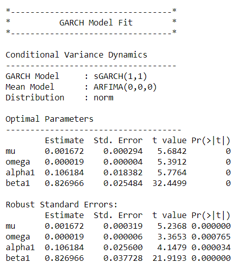

## Resumen de modelo ajustado GARCH(1,1)

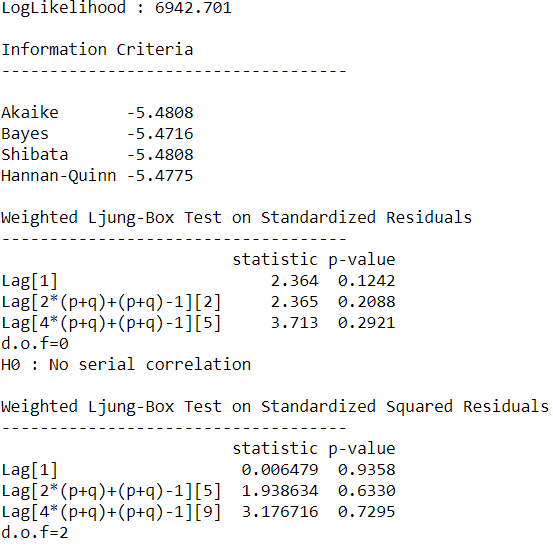

## Resumen de modelo ajustado GARCH(1,1)

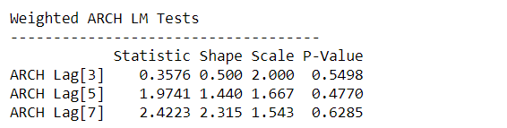

## Pruebas de diágnostico

**Prueba de Ljung-Box:** La hipótesis nula de la prueba es que la autocorrelación entre los residuos para un conjunto de rezagos k = 0. Si al menos una autocorrelación para un conjunto de rezagos k>0, el estadístico de prueba indicará que se debe rechazar la hipótesis nula.

El paquete rugarch para R, pondera los residuos estandarizados y los residuos cuadrados estandarizados. Si el valor p <= 0.05 ($\alpha$), entonces se rechazará la H0 y el modelo GARCH no habrá capturado la autocorrelación de los residuos.

**Prueba ARCH LM:** Busca evaluar la dependencia serial (autocorrelación) debido a un proceso de varianza condicional, evaluando la autocorrelación dentro de los residuos al cuadrado. La H0 es que la autocorrelación de los residuos para un conjunto de rezagos k=0.

## Resumen de modelo ajustado GARCH(1,1)

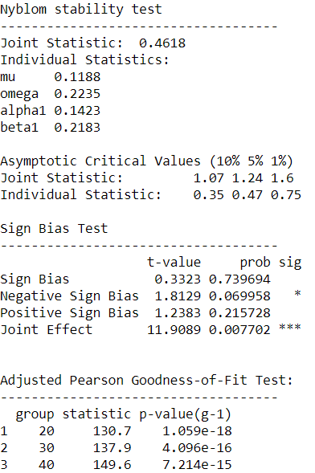

## Pruebas de diágnostico

**Prueba de estabilidad Nyblom:** Busca evaluar la existencia de un cambio estructural dentro de la series analizada. La H0 es que los valores de los parámetros son constantes, es decir, de varianza cero, la Ha es que la varianza > 0.

**Prueba de sesgo de signo:** Proporcionan un medio para probar la especificación errónea de los modelos de volatilidad condicional. Examinan si el residuo al cuadrado estandarizado es predecible usando variables (dummy) indicativas. La H0 es que los parámetros adicionales correspondientes a las variables adicionales (dummy) = 0. La Ha es que estos parámetros son $\not=$ 0, lo que indica mala especificacion del modelo.

**Prueba de bondad de ajuste de Pearson ajustada:** Compara la distribución empírica de los residuos estandarizados con la distribucion teórica seleccionada. La H0 es que ambas distribuciones son iguales.

## Funciones de Extracción

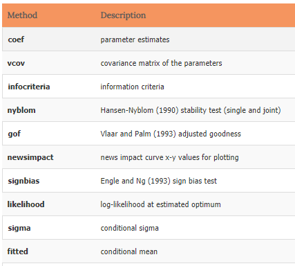

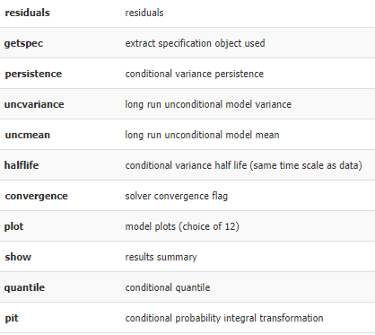

```r
infocriteria(garch11.fit)
```

A matrix: 4 × 1 of type dbl

| Akaike | -5.480806 |
| --- | --- |
| Bayes | -5.471585 |
| Shibata | -5.480811 |
| Hannan-Quinn | -5.477461 |

## Método gráfico del objeto uGARCHfit

selection:

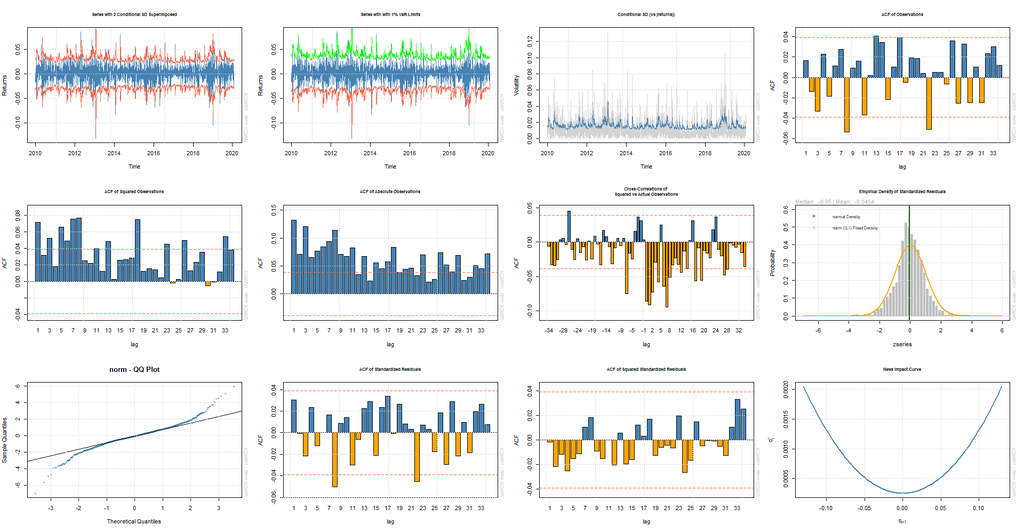

# Otras estimaciones del modelo

```r
# Estimando distintos modelos GARCH

# Primero se deben calcular los objetos tipo uGARCHspec y luego se realizan
# los ajustes de los modelos por medio de uGARCHfit

###  Modelo 2: ARMA(0,0)-GARCH(1,1) modelo con distribucion t  ###
garch11.t.spec=ugarchspec(variance.model=list(garchOrder=c(1,1)), mean.model=list(armaOrder=c(0,0)), distribution.model = "std")

    #estimando modelo
garch11.t.fit=ugarchfit(spec=garch11.t.spec, data=apple_retl)

### Modelo 3:ARMA(0,0)-GARCH(1,1) modelo con distribucion t sesgada ###
garch11.skt.spec=ugarchspec(variance.model=list(garchOrder=c(1,1)), mean.model=list(armaOrder=c(0,0)), distribution.model = "sstd")

    #estimando modelo
garch11.skt.fit=ugarchfit(spec=garch11.skt.spec, data=apple_retl)
```

```r
###  Modelo 4: Fit ARMA(0,0)-eGARCH(1,1) modelo con distribucion t  ###
egarch11.t.spec=ugarchspec(variance.model=list(model = "eGARCH", garchOrder=c(1,1)), mean.model=list(armaOrder=c(0,0)), distribution.model = "std")
#setstart(egarch11.t.spec) <- list(shape = 5)
#setfixed(egarch11.t.spec) <- list(mu = 0.01, omega = 1e-05, alpha1 = 0.03, beta1 = 0.9, gamma1 = 0.01, shape = 5)

    #estimando modelo
egarch11.t.fit=ugarchfit(spec=egarch11.t.spec, data=apple_retl)

###  Modelo 5: Fit ARMA(0,0)-fGARCH(1,1) modelo con distribucion t  ###
fgarch11.t.spec=ugarchspec(variance.model=list(model = "fGARCH", garchOrder=c(1,1), submodel = "APARCH"), mean.model=list(armaOrder=c(0,0)), distribution.model = "std")

    #estimando modelo
fgarch11.t.fit=ugarchfit(spec=fgarch11.t.spec, data=apple_retl)

### Modelo 6: Modelo Igarch
igarch11.t.spec=ugarchspec(variance.model=list(model = "iGARCH", garchOrder=c(1,1)), mean.model=list(armaOrder=c(0 , 0 )), distribution.model = "std")

    #estimando modelo
igarch11.t.fit=ugarchfit(spec=igarch11.t.spec, data=apple_retl)
```

# Comparación por medio de los criterios de información

```r
infocriteria(garch11.fit)
infocriteria(egarch11.t.fit) # seleccionado por criterio Bayes
```

A matrix: 4 × 1 of type dbl

| Akaike | -5.480806 |
| --- | --- |
| Bayes | -5.471585 |
| Shibata | -5.480811 |
| Hannan-Quinn | -5.477461 |

A matrix: 4 × 1 of type dbl

| Akaike | -5.619298 |
| --- | --- |
| Bayes | -5.605467 |
| Shibata | -5.619309 |
| Hannan-Quinn | -5.614280 |

# Pronóstico y Diagnóstico del Modelo

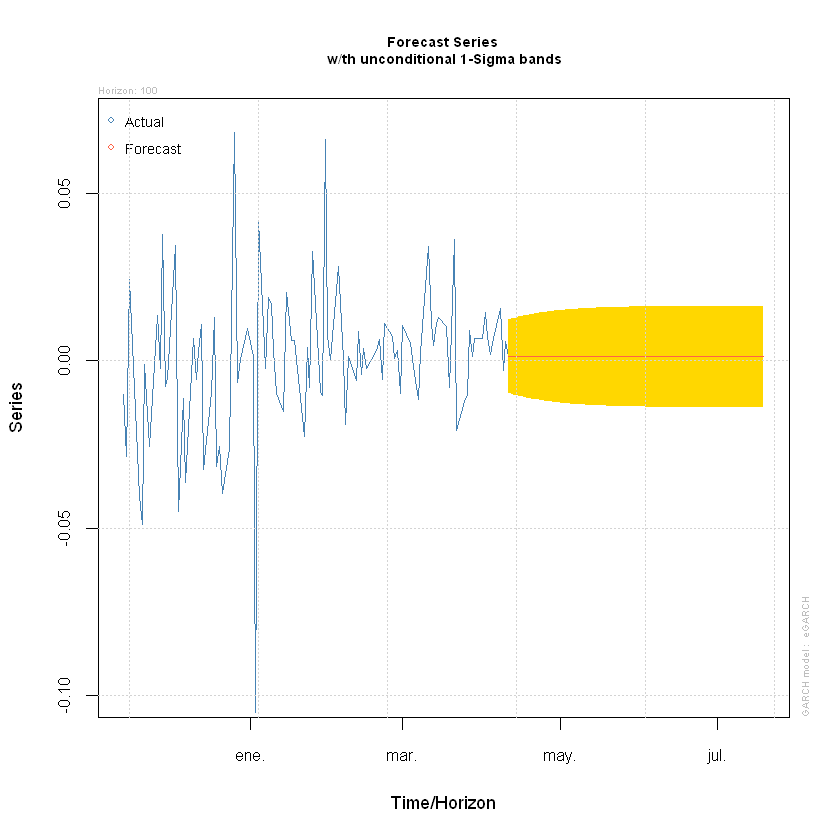

```r
egarch11.t.spec=ugarchspec(variance.model=list(model = "eGARCH", garchOrder=c(1,1)), mean.model=list(armaOrder=c(0,0)), distribution.model = "std")
egarch11.t.fit=ugarchfit(spec=egarch11.t.spec, data=apple_retl, out.sample = 200)
forc1 = ugarchforecast(egarch11.t.fit, n.ahead=100)
plot(forc1, which = 1)
```

```r
forc1
```

```
*------------------------------------*
*       GARCH Model Forecast         *
*------------------------------------*
Model: eGARCH
Horizon: 100
Roll Steps: 0
Out of Sample: 100

0-roll forecast [T0=2019-04-10]:
        Series   Sigma
T+1   0.001145 0.01099
T+2   0.001145 0.01120
T+3   0.001145 0.01140
T+4   0.001145 0.01160
T+5   0.001145 0.01178
T+6   0.001145 0.01196
T+7   0.001145 0.01213
T+8   0.001145 0.01229
T+9   0.001145 0.01245
T+10  0.001145 0.01259
T+11  0.001145 0.01273
T+12  0.001145 0.01287
T+13  0.001145 0.01299
T+14  0.001145 0.01311
T+15  0.001145 0.01323
T+16  0.001145 0.01333
T+17  0.001145 0.01344
T+18  0.001145 0.01353
T+19  0.001145 0.01362
T+20  0.001145 0.01371
T+21  0.001145 0.01379
T+22  0.001145 0.01387
T+23  0.001145 0.01394
T+24  0.001145 0.01401
T+25  0.001145 0.01408
T+26  0.001145 0.01414
T+27  0.001145 0.01420
T+28  0.001145 0.01425
T+29  0.001145 0.01430
T+30  0.001145 0.01435
```

[output cut: 55 more lines]

```
T+86  0.001145 0.01512
T+87  0.001145 0.01512
T+88  0.001145 0.01513
T+89  0.001145 0.01513
T+90  0.001145 0.01513
T+91  0.001145 0.01513
T+92  0.001145 0.01513
T+93  0.001145 0.01513
T+94  0.001145 0.01513
T+95  0.001145 0.01513
T+96  0.001145 0.01513
T+97  0.001145 0.01513
T+98  0.001145 0.01514
T+99  0.001145 0.01514
T+100 0.001145 0.01514
```

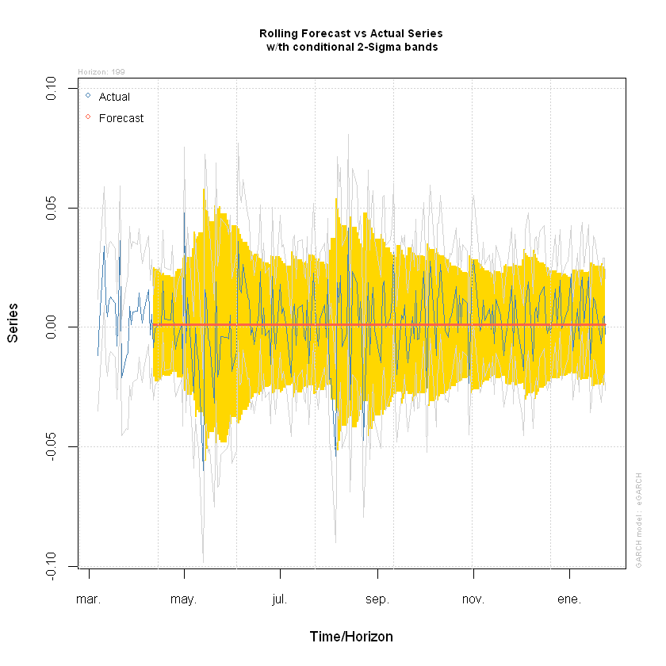

```r
forc2 = ugarchforecast(egarch11.t.fit, n.ahead=100, n.roll=199)
plot(forc2, which=2)
```

```r
forc2
```

```
*------------------------------------*
*       GARCH Model Forecast         *
*------------------------------------*
Model: eGARCH
Horizon: 100
Roll Steps: 199
Out of Sample: 100

0-roll forecast [T0=2019-04-10]:
        Series   Sigma
T+1   0.001145 0.01099
T+2   0.001145 0.01120
T+3   0.001145 0.01140
T+4   0.001145 0.01160
T+5   0.001145 0.01178
T+6   0.001145 0.01196
T+7   0.001145 0.01213
T+8   0.001145 0.01229
T+9   0.001145 0.01245
T+10  0.001145 0.01259
T+11  0.001145 0.01273
T+12  0.001145 0.01287
T+13  0.001145 0.01299
T+14  0.001145 0.01311
T+15  0.001145 0.01323
T+16  0.001145 0.01333
T+17  0.001145 0.01344
T+18  0.001145 0.01353
T+19  0.001145 0.01362
T+20  0.001145 0.01371
T+21  0.001145 0.01379
T+22  0.001145 0.01387
T+23  0.001145 0.01394
T+24  0.001145 0.01401
T+25  0.001145 0.01408
T+26  0.001145 0.01414
T+27  0.001145 0.01420
T+28  0.001145 0.01425
T+29  0.001145 0.01430
T+30  0.001145 0.01435
```

[output cut: 55 more lines]

```
T+86  0.001145 0.01512
T+87  0.001145 0.01512
T+88  0.001145 0.01513
T+89  0.001145 0.01513
T+90  0.001145 0.01513
T+91  0.001145 0.01513
T+92  0.001145 0.01513
T+93  0.001145 0.01513
T+94  0.001145 0.01513
T+95  0.001145 0.01513
T+96  0.001145 0.01513
T+97  0.001145 0.01513
T+98  0.001145 0.01514
T+99  0.001145 0.01514
T+100 0.001145 0.01514
```

# La librería también es capaz de pronosticar a través de GARCH-Bootstrap

```r
bootf = ugarchboot(egarch11.t.fit, data = NULL, method = c("Partial", "Full")[1],
                   sampling = c("raw", "kernel", "spd"), spd.options = list(upper = 0.9,lower = 0.1, type = "pwm", kernel = "normal"), n.ahead = 500,
                   n.bootfit = 100, n.bootpred = 500, out.sample = 0, rseed = NA, solver = "solnp", solver.control = list(), fit.control = list())
```

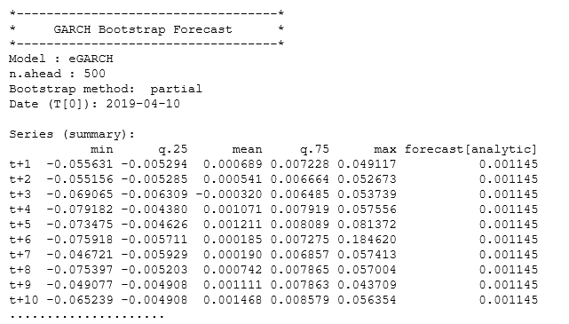

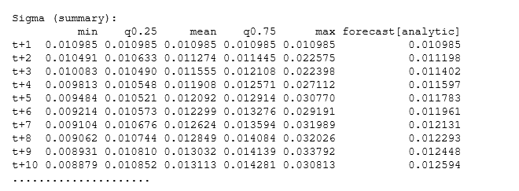

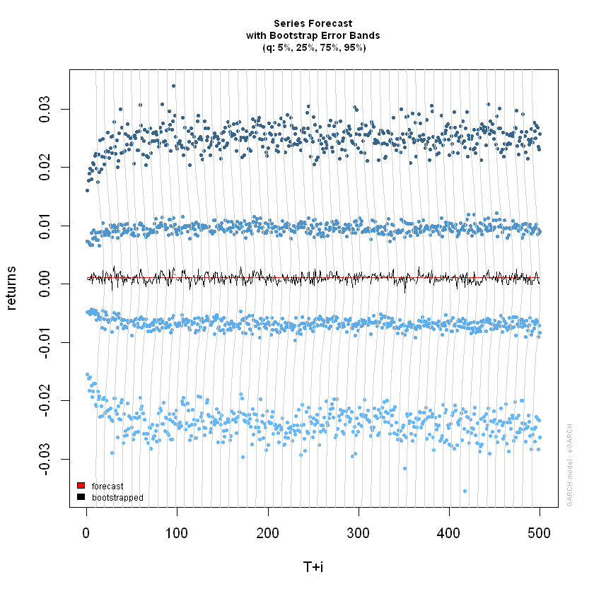

```r
plot(bootf, which = 2)
```

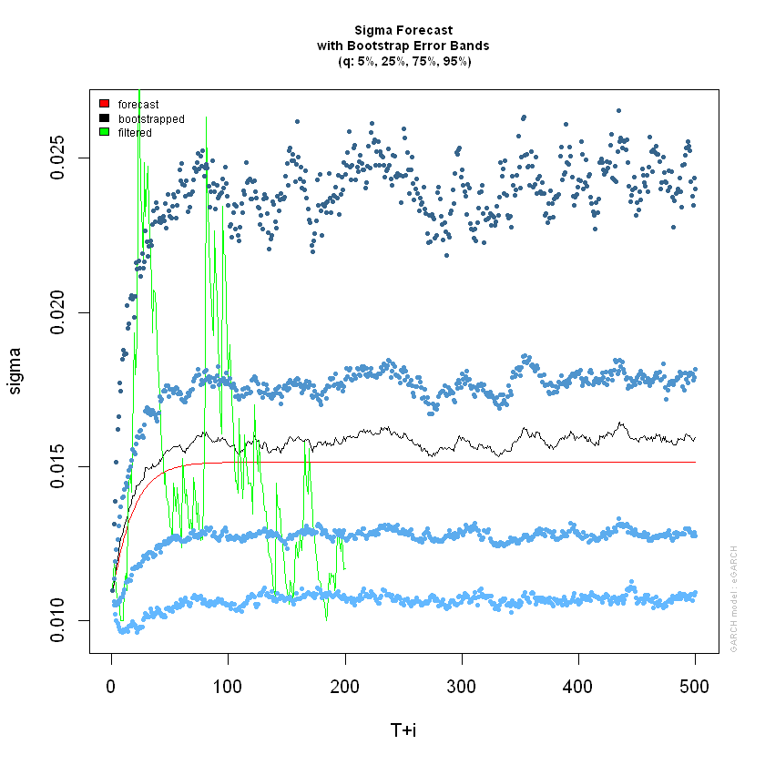

```r
plot(bootf, which = 3)
```

# Incertidumbre de parámetros y densidad simulada: distribución de uGARCH

Este metodo permite la generacion de la densidad de los parametros simulados de un conjunto de parametros de un modelo, el error cuadratico medio (RMSE) de parametros verdaderos vs estimados en relacion con el tamaño de los datos.

El metodo toma un objeto clase uGARCHfit o uno de clase uGARCHspec con parametros fijos. A continuacion un ejemplo

```r
cl = makePSOCKcluster(10)

gd = ugarchdistribution(garch11.fit, n.sim = 500, recursive = TRUE, recursive.length = 6000, recursive.window = 500, m.sim = 100, solver = 'hybrid', cluster = cl)
stopCluster(cl)
show(gd)
```

```
*------------------------------------*
*    GARCH Parameter Distribution    *
*------------------------------------*
Model : sGARCH
No. Paths (m.sim) : 100
Length of Paths (n.sim) : 500
Recursive : TRUE
Recursive Length : 6000
Recursive Window : 500

Coefficients: True vs Simulation Mean (Window-n)
                   mu      omega  alpha1   beta1
true-coef   0.0016719 1.8921e-05 0.10618 0.82697
window-500  0.0017024 2.3219e-05 0.10589 0.81145
window-1000 0.0017573 2.1672e-05 0.11182 0.81191
window-1500 0.0016457 2.1755e-05 0.10850 0.81420
window-2000 0.0016455 2.0957e-05 0.10647 0.81822
window-2500 0.0016534 2.0369e-05 0.10806 0.82037
window-3000 0.0016044 2.0106e-05 0.10412 0.82482
window-3500 0.0016599 1.9624e-05 0.10637 0.82436
window-4000 0.0016949 1.9025e-05 0.10778 0.82499
window-4500 0.0016908 1.9144e-05 0.10545 0.82688
window-5000 0.0016774 1.8969e-05 0.10445 0.82772
window-5500 0.0017054 1.9722e-05 0.10729 0.82311
window-6000 0.0016717 1.9760e-05 0.10637 0.82361
```

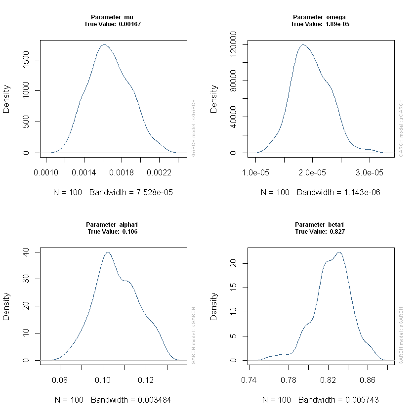

```r
plot(gd, which = 1, window = 12)
```

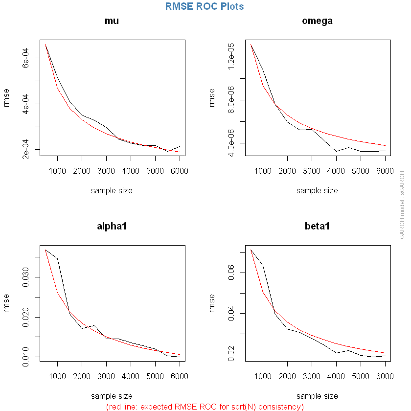

```r
plot(gd, which = 4, window = 12)
```

```r
cl4 = makePSOCKcluster(15)

gd4 = ugarchdistribution(egarch11.t.fit, n.sim = 500, recursive = TRUE, recursive.length = 6000, recursive.window = 500, m.sim = 100, solver = 'hybrid', cluster = cl4)
stopCluster(cl4)
show(gd4)
```

```
*------------------------------------*
*    GARCH Parameter Distribution    *
*------------------------------------*
Model : eGARCH
No. Paths (m.sim) : 100
Length of Paths (n.sim) : 500
Recursive : TRUE
Recursive Length : 6000
Recursive Window : 500

Coefficients: True vs Simulation Mean (Window-n)
                   mu    omega   alpha1   beta1  gamma1  shape
true-coef   0.0011448 -0.50038 -0.11711 0.94029 0.17946 4.6340
window-500  0.0011915 -0.65034 -0.12561 0.92272 0.16622 5.1947
window-1000 0.0011109 -0.53829 -0.12015 0.93579 0.16623 4.8785
window-1500 0.0010762 -0.51406 -0.11944 0.93866 0.17283 4.7472
window-2000 0.0011033 -0.52531 -0.11680 0.93735 0.17120 4.6778
window-2500 0.0011558 -0.50953 -0.11490 0.93930 0.17618 4.6996
window-3000 0.0011135 -0.52786 -0.11741 0.93704 0.17709 4.6491
window-3500 0.0011319 -0.51935 -0.11746 0.93798 0.17649 4.6526
window-4000 0.0011049 -0.50791 -0.11830 0.93933 0.17832 4.6527
window-4500 0.0011288 -0.51152 -0.11790 0.93891 0.17854 4.6608
window-5000 0.0011540 -0.51646 -0.12011 0.93828 0.17998 4.6294
window-5500 0.0011142 -0.51813 -0.11758 0.93814 0.17997 4.6825
window-6000 0.0011377 -0.50368 -0.11635 0.93984 0.17765 4.6720
```

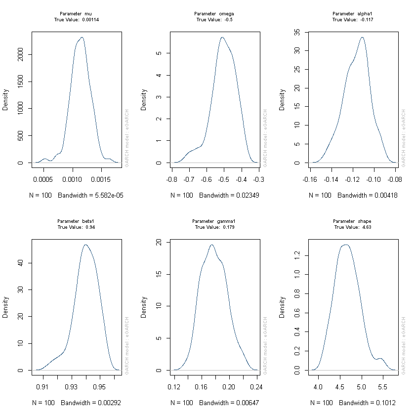

```r
plot(gd4, which = 1, window = 12)
```

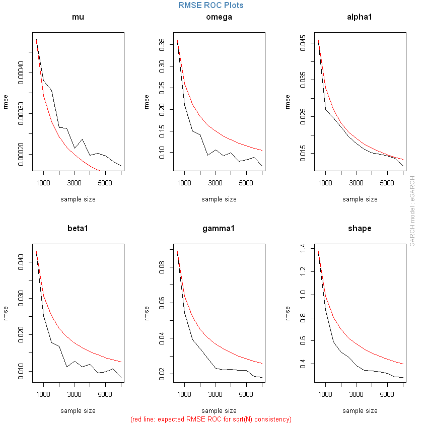

```r
plot(gd4, which = 4, window = 12)
```

# Un tip para el futuro

```r
COLOR = colorMatrix() #Genera una matriz con todos los colores disponibles en R, para utilizarlos en las gráficas por ejemplo
```

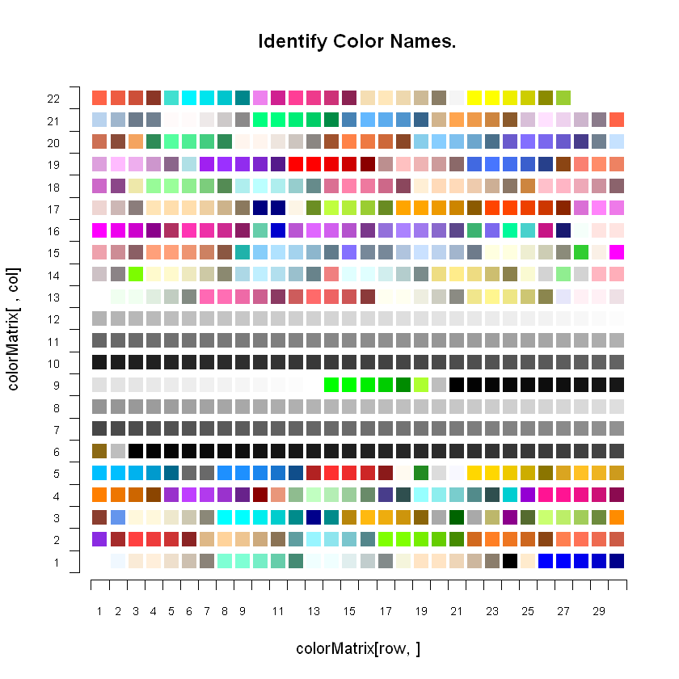

```r
colorLocator(locator = FALSE, cex.axis = 0.7)
```